# Outliers

Bryana Benson

Conner Bryan

```r
library(readr)
library(dplyr)
library(ggplot2)
```

```r
data <- read_csv("cricket.csv")
head(data)
```

| Batsman | Country | Period | Average |
| --- | --- | --- | --- |
| Bradman, D G | Australia | 1928-1948 | 99.94 |
| Smith, S P D* | Australia | 2010- | 61.38 |
| Sutcliffe, H | England | 1924-1935 | 60.73 |
| Barrington, K F | England | 1955-1968 | 58.67 |
| Weekes, E D C | West Indies | 1948-1958 | 58.62 |
| Hammond, W R | England | 1927-1947 | 58.46 |

```r
str(data)
```

```
Classes ‘tbl_df’, ‘tbl’ and 'data.frame':   60 obs. of  4 variables:
 $ Batsman: chr  "Bradman, D G" "Smith, S P D*" "Sutcliffe, H" "Barrington, K F" ...
 $ Country: chr  "Australia" "Australia" "England" "England" ...
 $ Period : chr  "1928-1948" "2010-" "1924-1935" "1955-1968" ...
 $ Average: num  99.9 61.4 60.7 58.7 58.6 ...
 - attr(*, "spec")=List of 2
  ..$ cols   :List of 4
  .. ..$ Batsman: list()
  .. .. ..- attr(*, "class")= chr  "collector_character" "collector"
  .. ..$ Country: list()
  .. .. ..- attr(*, "class")= chr  "collector_character" "collector"
  .. ..$ Period : list()
  .. .. ..- attr(*, "class")= chr  "collector_character" "collector"
  .. ..$ Average: list()
  .. .. ..- attr(*, "class")= chr  "collector_double" "collector"
  ..$ default: list()
  .. ..- attr(*, "class")= chr  "collector_guess" "collector"
  ..- attr(*, "class")= chr "col_spec"
```

### Is Bradman an outlier?

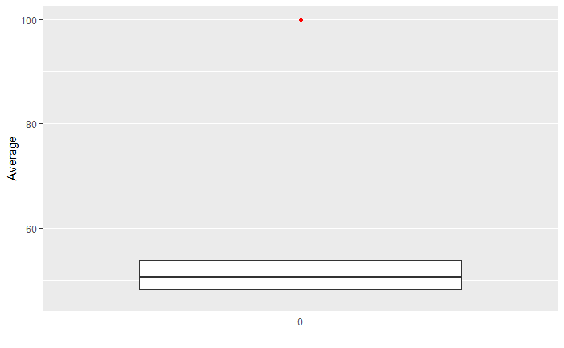

```r
ggplot(data = data ,aes(factor(0),Average)) +
  geom_boxplot(outlier.colour='red') + xlab("") + ylab("Average")
```

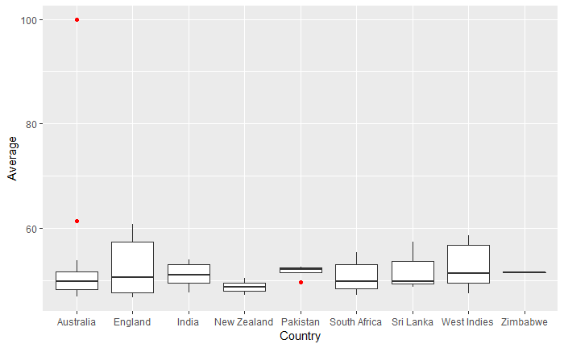

```r
ggplot(data = data ,aes(Country,Average)) +
  geom_boxplot(outlier.colour='red') + xlab("Country") + ylab("Average")
```

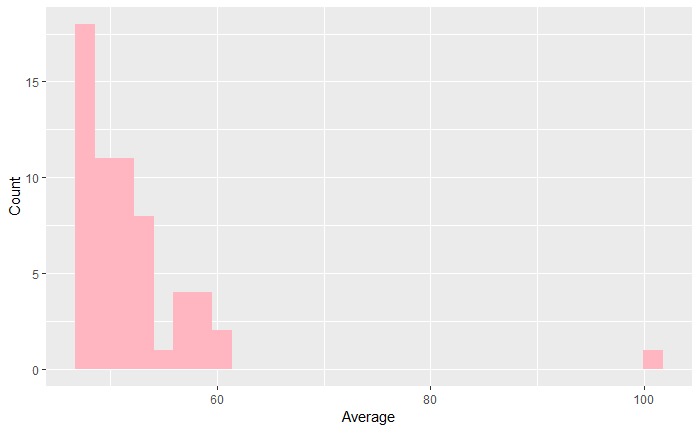

```r
ggplot(data = data, aes(Average)) +
  geom_histogram(fill = "light pink")  +
  xlab("Average") +
  ylab("Count")
```

```r
#Conducting a Shapiro-Wilk test for normality
#A small p-value indicates a low probability that data is normally distributed
shapiro.test(data$Average)
```

```
    Shapiro-Wilk normality test

data:  data$Average
W = 0.55016, p-value = 2.782e-12
```

The p-value for the Shapiro-Wilk test for Normality is less than .0000. This indicates that the data is NOT normally distributed.

```r
#Using Residual analysis for testing outlier status
lmAverage<-lm(Average ~ Country, data=data) # linear regression model
data$Predictions <- predict(lmAverage, newdata=data)
data$Residuals <- data$Average - data$Predictions
head(data)
```

| Batsman | Country | Period | Average | Predictions | Residuals |
| --- | --- | --- | --- | --- | --- |
| Bradman, D G | Australia | 1928-1948 | 99.94 | 53.41875 | 46.521250 |
| Smith, S P D* | Australia | 2010- | 61.38 | 53.41875 | 7.961250 |
| Sutcliffe, H | England | 1924-1935 | 60.73 | 52.49250 | 8.237500 |
| Barrington, K F | England | 1955-1968 | 58.67 | 52.49250 | 6.177500 |
| Weekes, E D C | West Indies | 1948-1958 | 58.62 | 52.46778 | 6.152222 |
| Hammond, W R | England | 1927-1947 | 58.46 | 52.49250 | 5.967500 |

A linear regression model was created predicting the Average based on Country. Those Average Predictions were stored in the dataset. The residuals were also stored in the dataset.

```r
#Test to see if Residuals are normally distributed
shapiro.test(data$Residuals)
```

```
    Shapiro-Wilk normality test

data:  data$Residuals
W = 0.59065, p-value = 1.138e-11
```

The p-value of the Shapiro-Wilks test is less than .0000 which suggests the residuals are NOT normally distributed and suggests a trend or pattern.

```r
###Using manipulated data for testing/visualizing
noBradman <- filter(data, Batsman != "Bradman, D G")
```

Exluded Brandman from the dataset.

```r
shapiro.test(noBradman$Average) #running test without Bradman gives less certainty
```

```
    Shapiro-Wilk normality test

data:  noBradman$Average
W = 0.89728, p-value = 0.0001192
```

```r
shapiro.test(noBradman$Residuals) #running residual test without Bradman
```

```
    Shapiro-Wilk normality test

data:  noBradman$Residuals
W = 0.9364, p-value = 0.00412
```

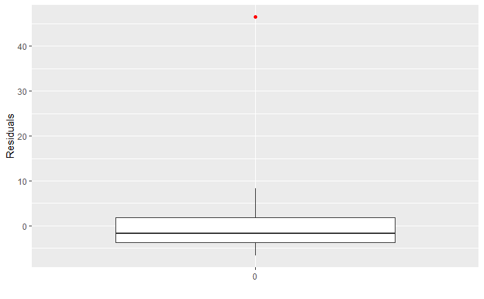

```r
ggplot(data,aes(factor(0),Residuals)) +
  geom_boxplot(outlier.colour='red') + xlab("") + ylab("Residuals") #plotting residuals
```

```r
#Calculating how far Bradman is from "average"
avg_Average<-mean(data$Residuals) #the average of all residuals
data[1,6] - (avg_Average + (3*sd(data$Residuals)))
```

| Residuals |
| --- |
| 24.77986 |

```r
#the difference between Bradman's residual and 3 deviations above the mean
```

### CONCLUSIONS

Bradman is an outlier. A quick boxplot seems to confirm this fact. Even when segmenting out results by country, Bradman appears as an outlier in Australia. When Bradman is removed from the sample, it conforms more closely to a normal distribution. Even an analysis of the residuals with Country as the explanatory variable reveals that Bradman is far removed from any sort of standard deviation of the group.